# Open The Course Project And Render A Notebook

# Goal

This notebook is the first live workflow walkthrough.

We will use it to get everyone oriented in RStudio or Positron, confirm that the course project is open, run the course updater, copy practice notebooks into your work folder, and render a notebook to HTML.

By the end, you should know how to:

- open the course project
- find the main course folders
- update course materials with `source("updater.R")`
- work from `practice/work/`
- run code chunks
- render a Quarto notebook
- find the rendered HTML output

# What We Are Opening

The course materials are stored in a GitHub repository.

In class, we will open the repository in RStudio and work from the project root. The project root is the folder that contains:

- `data-visualization-course.Rproj`
- `updater.R`
- `modules/`
- `practice/`
- `data/`
- `slides/`
- `assignments/`

# Get The Course Materials

In RStudio, use the Git project workflow shown in class.

The instructor will walk through:

- opening RStudio
- choosing the GitHub repository option
- pasting the course repository URL
- choosing where to store the project on your computer
- opening the project after it downloads

If you already have the course project, open the existing project instead of downloading it again.

# Confirm The Project Is Open

In RStudio, the top-right project menu should show the course project.

In the Files pane, you should see the course folders and files.

Now run this chunk.

```r
getwd()
```

```
[1] "/Users/erik/Projects/data-visualization-course/modules/01-workflow-and-basics"
```

You should be working inside the course project folder.

# Find This Module

This notebook lives here:

```
modules/01-workflow-and-basics/01_open-render-check.qmd
```

Open it from the Files pane or from the file path shown by the instructor.

# Run The Course Updater

The course materials may be updated during the week.

Run this in the R Console from the project root:

```r
source("updater.R")
```

The updater does two things:

- pulls course updates from GitHub if this folder is a Git clone
- copies missing practice templates into `practice/work/`

It does not overwrite files that already exist in `practice/work/`.

# Check The Practice Work Folder

Your own practice notebooks should live in:

```
practice/work/
```

The updater copies starter notebooks from:

```
practice/templates/
```

Do not edit files in `practice/templates/` if you want to keep your work. Those files may be updated by the instructor.

# Check R Code

Run a simple calculation.

```r
2 + 2
```

```
[1] 4
```

Create a small object.

```r
favorite_number <- 42
favorite_number
```

```
[1] 42
```

# Check Data

For this workflow check, we will use the built-in `mtcars` dataset so nothing else has to be loaded.

```r
mtcars |>
  head()
```

```
                   mpg cyl disp  hp drat    wt  qsec vs am gear carb
Mazda RX4         21.0   6  160 110 3.90 2.620 16.46  0  1    4    4
Mazda RX4 Wag     21.0   6  160 110 3.90 2.875 17.02  0  1    4    4
Datsun 710        22.8   4  108  93 3.85 2.320 18.61  1  1    4    1
Hornet 4 Drive    21.4   6  258 110 3.08 3.215 19.44  1  0    3    1
Hornet Sportabout 18.7   8  360 175 3.15 3.440 17.02  0  0    3    2
Valiant           18.1   6  225 105 2.76 3.460 20.22  1  0    3    1
```

```r
mtcars |>
  summarise(
    rows = n(),
    average_mpg = mean(mpg),
    minimum_mpg = min(mpg),
    maximum_mpg = max(mpg)
  )
```

```
  rows average_mpg minimum_mpg maximum_mpg
1   32    20.09062        10.4        33.9
```

# Check Plotting

Make a quick plot.

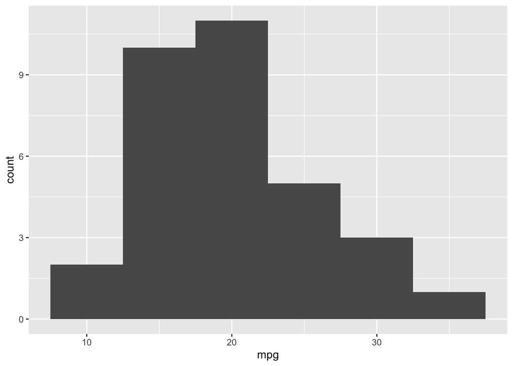

```r
p1 <- ggplot(mtcars, aes(x = mpg)) +
  geom_histogram(binwidth = 5)

p1
```

Now add labels.

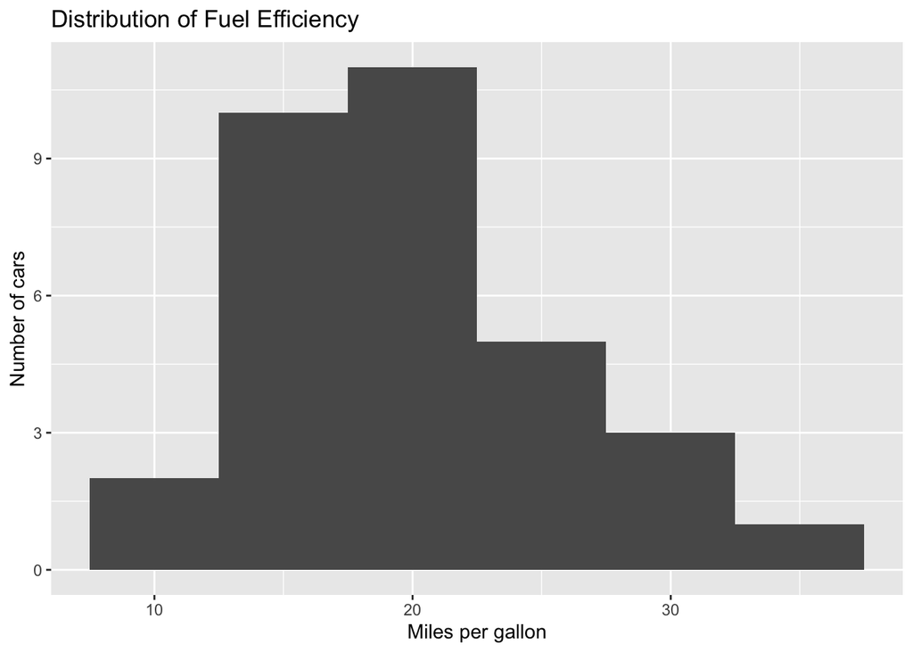

```r
p2 <- p1 +
  labs(
    title = "Distribution of Fuel Efficiency",
    x = "Miles per gallon",
    y = "Number of cars"
  )

p2
```

# Render The Notebook

Now render the notebook.

In RStudio, click the Render button. In Positron, click Preview.

After rendering, confirm that:

- an HTML file was created
- the HTML file opens in the Viewer, browser, or preview pane
- the plot appears in the rendered file
- the text and code output appear in the rendered file

# What To Do Next

After this workflow check:

1. Open a practice notebook from `practice/work/`.
2. Run its setup chunk.
3. Work through the prompts.
4. Render it to HTML.
5. Keep your edited practice files in `practice/work/`.

# Troubleshooting Notes

Common problems:

- The notebook was opened outside the course project.
- R or Quarto is not installed correctly.
- The first code chunk did not run.
- `source("updater.R")` was run from the wrong folder.
- The render failed because an earlier chunk had an error.

When something fails, read the first error message carefully and fix that first.